# R Notebook

Tutorial: https://satijalab.org/seurat/cell_cycle_vignette.html

```r
library(Seurat)
```

```r
seurobj <- readRDS('data/10x-normalized-scaled-clustered-tsne.rds')
```

Inspect genes that account for the largest variation in the dataset. (Cell cycle genes MKI67 and CENPF in PC1).

```r
PrintPCA(seurobj, pcs.print=1:10, genes.print=5)
```

```
[1] "PC1"
[1] "MKI67" "H2AFZ" "UBE2S" "CENPF" "CKS2"
[1] ""
[1] "EEF1A1"  "NNMT"    "TPD52L1" "NEAT1"   "EFEMP1"
[1] ""
[1] ""
[1] "PC2"
[1] "FTH1"     "RPS2"     "VIM"      "RPS29"    "SERPINE1"
[1] ""
[1] "RPSA"   "CYP1B1" "DCN"    "NNMT"   "MYH10"
[1] ""
[1] ""
[1] "PC3"
[1] "RPS29"  "RPS27"  "VEPH1"  "ANKRD1" "HOXC8"
[1] ""
```

[output cut: 45 more lines]

Assign cell cycle scores. Assign each cell a score based on the expression of G2/M and S phase markers. The cell cycle marker genes are obtained from Tirosh et al, 2015.

|  | S.Score | G2M.Score | Phase |
| --- | --- | --- | --- |
| AAACCTGAGCTCCCAG-1 | -0.09221130 | -0.2858032 | G1 |
| AAACCTGAGGCGCTCT-1 | -0.16356241 | -0.3106313 | G1 |
| AAACCTGCAATCTACG-1 | -0.08500159 | -0.3132072 | G1 |
| AAACCTGCAATGACCT-1 | -0.13117250 | -0.2572319 | G1 |
| AAACGGGAGTGGGTTG-1 | -0.11880410 | -0.3339953 | G1 |
| AAACGGGCAAGTACCT-1 | -0.16640343 | -0.3058894 | G1 |

Visualize the distribution of some cell cycle markers. Most cells seem to express neither of the markers here.

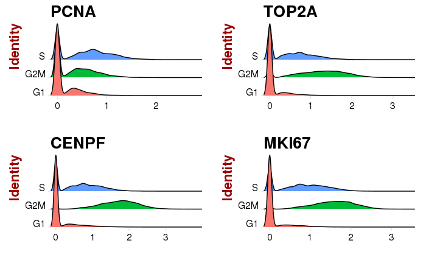

```r
RidgePlot(seurobj, features.plot = c("PCNA", "TOP2A", "CENPF", "MKI67"), nCol = 2)
```

Plot the first two PCs, colored on cell cycle phase. The cell cycle effects clearly account for a large part of the variation in the dataset.

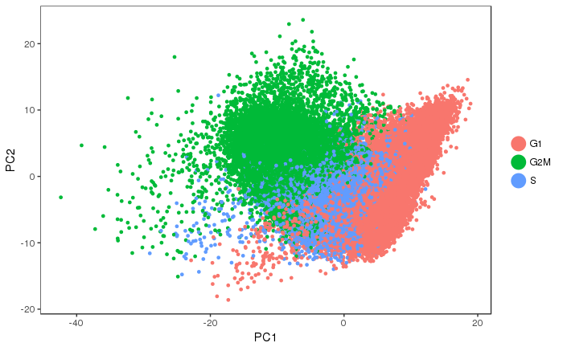

PCA only on cell cycle genes

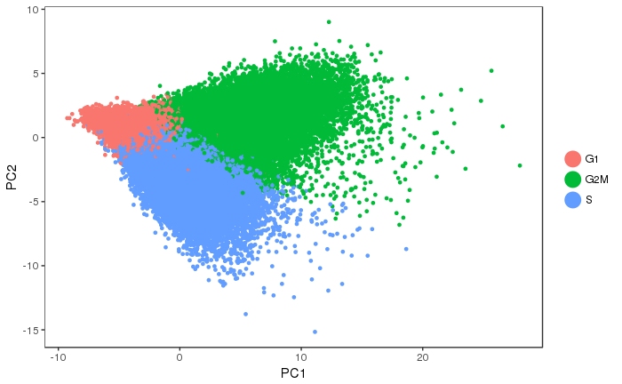

```r
seurobj2 <- RunPCA(object = seurobj, pc.genes = c(s.genes, g2m.genes), do.print = FALSE)
PCAPlot(object = seurobj2)
```

In the tSNE plot, cells of the same cell cycle group together.

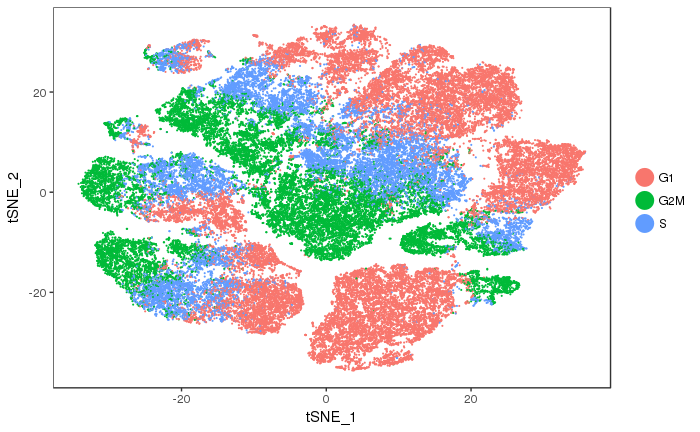

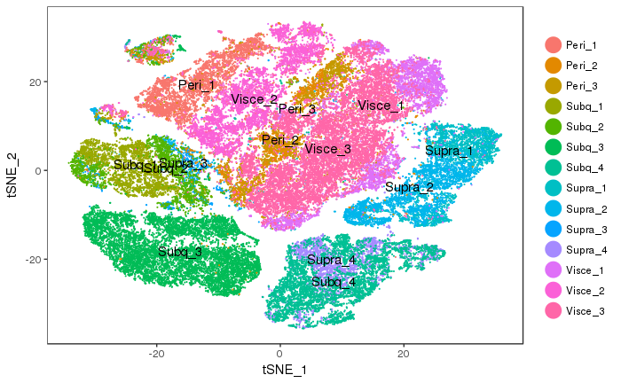

Regress the cell cycle effects out.

```r
seurobj <- ScaleData(seurobj, vars.to.regress = c("nUMI", "percent.mito", "S.Score", "G2M.Score"), display.progress = T)
saveRDS(seurobj, 'data/10x-normalized-scaled-clustered-ccregout.rds')
```

Check by plotting the first two PCs again.

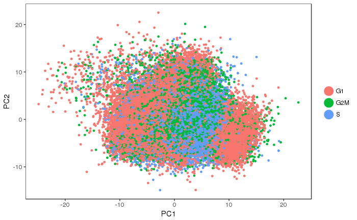

And PCA only on cell cycle genes

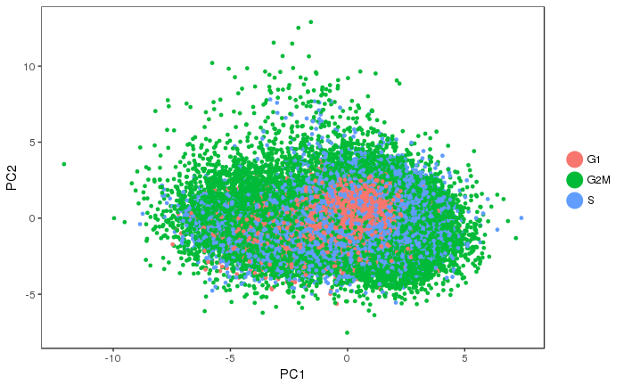

Run tSNE on the new data. Determine nr of PC’s to use.

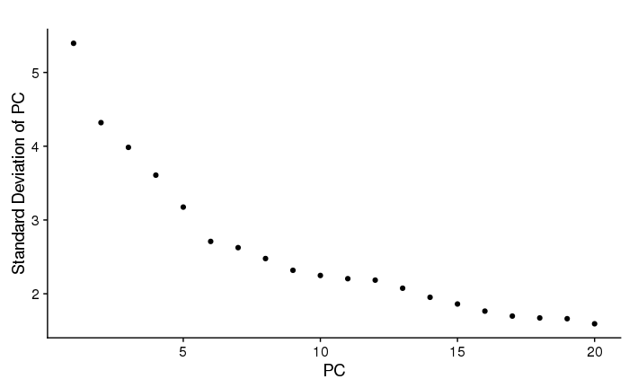

Cells in different stages of the cell cycle are now more mixed.

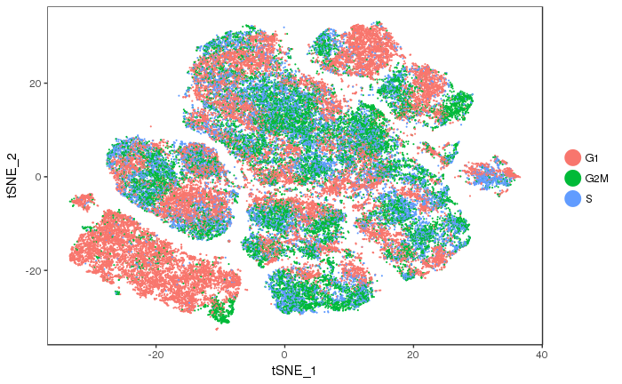

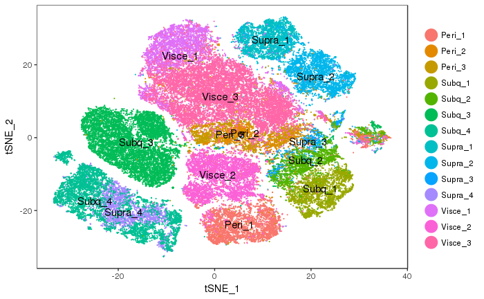

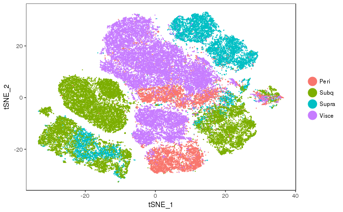